# Business Forecasting HW- Week 3

Juan Romo

Load Libraries

```r
library(ggplot2)
library(readxl)
library(gridExtra)
library(scales)
library(fpp)
library(fpp2)
library(TTR)
library(formattable)
```

Load Data

```r
Tesla_Clean_Data <- read_excel("C:/Users/jprom/Desktop/Class Notes/Class Fall 2023/Business Forecasting/Week 4/Week 4 HW/Tesla Clean Data.xlsx")

View(Tesla_Clean_Data)
```

Copy Data

```r
tsla_rev <- as.data.frame(Tesla_Clean_Data)

summary (tsla_rev)
```

```
   Qtr_Year           Qtr_End          Total Revenue     Auto_Service_Other Total_Auto_Rev     Auto_Rev       Auto_Lease_Rev
 Length:40          Length:40          Min.   :  431.3   Min.   : 1124      Min.   : 1026   Min.   :  901.9   Min.   :102.7
 Class :character   Class :character   1st Qu.: 1197.5   1st Qu.: 2992      1st Qu.: 2533   1st Qu.: 2242.9   1st Qu.:223.0
 Mode  :character   Mode  :character   Median : 4271.6   Median : 6203      Median : 5376   Median : 5168.0   Median :265.0
                                       Mean   : 7204.1   Mean   : 8792      Mean   : 7858   Mean   : 7509.0   Mean   :323.4
                                       3rd Qu.:10477.8   3rd Qu.:12502      3rd Qu.:11132   3rd Qu.:10773.0   3rd Qu.:358.5
                                       Max.   :24927.0   Max.   :23418      Max.   :21307   Max.   :20708.0   Max.   :668.0
                                                         NA's   :10         NA's   :9       NA's   :9         NA's   :9
  Auto_Credits    Service_Rev      Total_Energy_Rev   Energy_Sto_Rev   Energy_Sto_Lease_Rev Veh_Sold_World   Total_Sold_3_Y
 Min.   :282.0   Min.   :  84.22   Min.   :   3.947   Min.   : 173.0   Min.   :106.7        Min.   :  5516   Min.   :   222
 1st Qu.:341.8   1st Qu.: 266.78   1st Qu.: 295.519   1st Qu.: 239.4   1st Qu.:112.1        1st Qu.: 14820   1st Qu.: 57889
 Median :401.5   Median : 548.00   Median : 399.317   Median : 411.0   Median :129.9        Median : 40768   Median :102184
 Mean   :401.5   Mean   : 688.97   Mean   : 520.164   Mean   : 525.6   Mean   :129.8        Mean   :114135   Mean   :166095
 3rd Qu.:461.2   3rd Qu.: 922.50   3rd Qu.: 720.000   3rd Qu.: 655.2   3rd Qu.:145.8        3rd Qu.:184800   3rd Qu.:281126
 Max.   :521.0   Max.   :2150.00   Max.   :1529.000   Max.   :1413.0   Max.   :161.0        Max.   :466140   Max.   :446915
 NA's   :38      NA's   :9         NA's   :9          NA's   :20       NA's   :20           NA's   :3        NA's   :18
 Total_Sold_S_X   Total_Sold_X    Total_Sold_S   Total_Prod_World Total _Prod_3_Y  Total_Prod_S_X  Inv_Finish_Goods
 Min.   : 1890   Min.   :  206   Min.   : 9764   Min.   : 11160   Min.   :   260   Min.   :    0   Min.   :  69.32
 1st Qu.:12230   1st Qu.: 3519   1st Qu.:12210   1st Qu.: 25109   1st Qu.: 61789   1st Qu.:14218   1st Qu.: 668.66
 Median :17478   Median : 8774   Median :13450   Median : 81207   Median :107663   Median :18345   Median :1264.50
 Mean   :17293   Mean   : 7062   Mean   :13574   Mean   :134420   Mean   :170378   Mean   :17795   Mean   :1341.23
 3rd Qu.:22200   3rd Qu.:10775   3rd Qu.:15056   3rd Qu.:214272   3rd Qu.:278934   3rd Qu.:24761   3rd Qu.:1614.49
 Max.   :28425   Max.   :11865   Max.   :17272   Max.   :479700   Max.   :460211   Max.   :26903   Max.   :5193.00
 NA's   :11      NA's   :33      NA's   :33      NA's   :8        NA's   :18       NA's   :11
```

Drop all unnecessary columns

```r
tsla_rev <- tsla_rev[-c(1,4:21)]

head(tsla_rev)
```

|  | Qtr_End | Total Revenue |
| --- | --- | --- |
| 1 | 09/30/2013 | 431.346 |
| 2 | 12/31/2013 | 615.219 |
| 3 | 03/31/2014 | 620.542 |
| 4 | 06/30/2014 | 769.349 |
| 5 | 09/30/2014 | 851.804 |
| 6 | 12/31/2014 | 956.661 |

```r
NA
```

Check for missing values

```r
total_obs <- ncol(tsla_rev)*nrow(tsla_rev)

total_obs
```

```
[1] 80
```

```r
na_count <- sum(is.na(tsla_rev))

na_count
```

```
[1] 0
```

Convert Qtr_End column to date data type

```r
tsla_rev$Qtr_End <- as.Date(tsla_rev$Qtr_End,format = "%m/%d/%Y")

class(tsla_rev$Qtr_End)
```

```
[1] "Date"
```

```r
head(tsla_rev)
```

|  | Qtr_End | Total Revenue |
| --- | --- | --- |
| 1 | 2013-09-30 | 431.346 |
| 2 | 2013-12-31 | 615.219 |
| 3 | 2014-03-31 | 620.542 |
| 4 | 2014-06-30 | 769.349 |
| 5 | 2014-09-30 | 851.804 |
| 6 | 2014-12-31 | 956.661 |

```r
NA
```

Rename Columns

```r
colnames(tsla_rev) <- c('Qtr_End_Date', 'Total_Revenue')

head(tsla_rev)
```

|  | Qtr_End_Date | Total_Revenue |
| --- | --- | --- |
| 1 | 2013-09-30 | 431.346 |
| 2 | 2013-12-31 | 615.219 |
| 3 | 2014-03-31 | 620.542 |
| 4 | 2014-06-30 | 769.349 |
| 5 | 2014-09-30 | 851.804 |
| 6 | 2014-12-31 | 956.661 |

Convert Total Revenue to time Series

```r
tsla_rev$Total_Revenue <- ts(tsla_rev$Total_Revenue, start = c(2013,3), end = c(2023,2), frequency = 4)

class(tsla_rev$Total_Revenue)
```

```
[1] "ts"
```

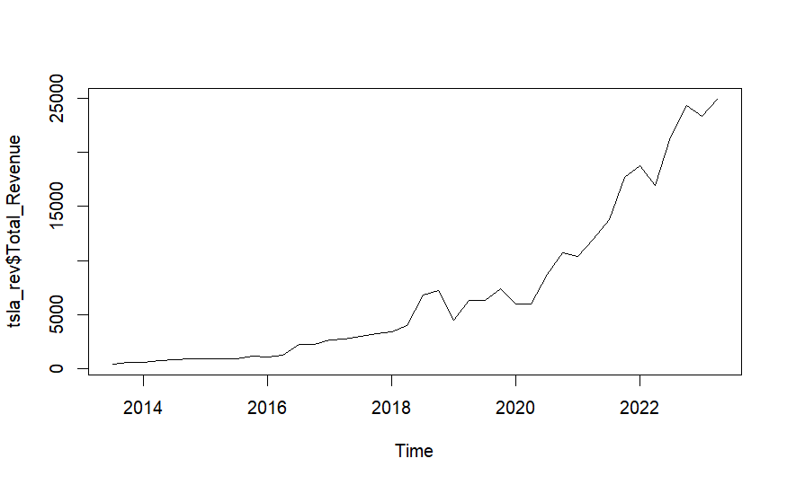

```r
plot(tsla_rev$Total_Revenue)
```

Take a subset of the last 5 years of data

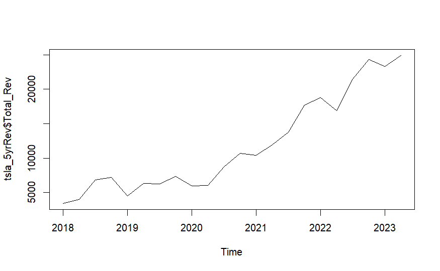

```r
tsla_5yrRev <- as.data.frame(window(tsla_rev$Total_Revenue, start = c(2018, 1), end = c(2023,2)))

colnames(tsla_5yrRev) <- c('Total_Rev')

plot(tsla_5yrRev$Total_Rev)
```

Revenue 5 Year Summary Statistics

```r
summary(tsla_5yrRev$Total_Rev)
```

```
   Min. 1st Qu.  Median    Mean 3rd Qu.    Max.
   3409    6315    9580   11869   17523   24927
```

Plot Histogram and Box Plot

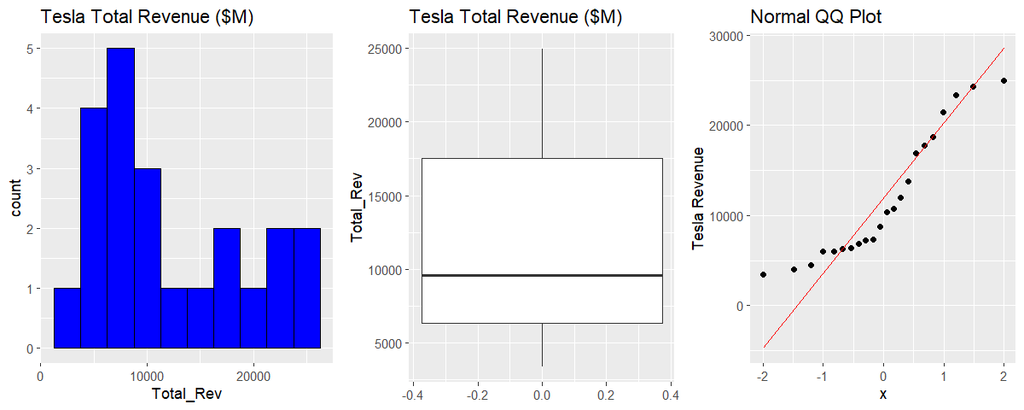

```r
hist_plot <- ggplot(tsla_5yrRev, aes(x = Total_Rev)) +
                    geom_histogram(binwidth = 2500, color = "Black", fill = "blue") +
                    labs(title = "Tesla Total Revenue ($M)")

box_plot <- ggplot(tsla_5yrRev, aes(y = Total_Rev)) +
                    geom_boxplot() +
                    labs(title = "Tesla Total Revenue ($M)")

qq_plot <- ggplot(tsla_5yrRev) +
                aes(sample = Total_Rev) +
                geom_qq() +
                geom_qq_line(color = "Red") +
                labs(title = "Normal QQ Plot", y = "Tesla Revenue")

grid.arrange(hist_plot,box_plot, qq_plot, ncol=3)
```

Observations:

- Tesla histogram and qq plot show revenue does not appear to be normally distributed and skewed right. This is congruent with the the plot of the time series where revenues are consistently increasing, with higher revenue occurring less frequently in more recent time periods.
- The box plot shows that the median revenue is approx. $10B. However, the range of the long tail is larger than the 1st and 2nd, which could be an indication of a significant change in the company that resulted in faster revenue growth.
- Possibly factors such as production capacity created a lower bound for revenue initially and were overcome once new production facilities were online, thus producing a right skewed distribution.

Auto- Correlation Plot

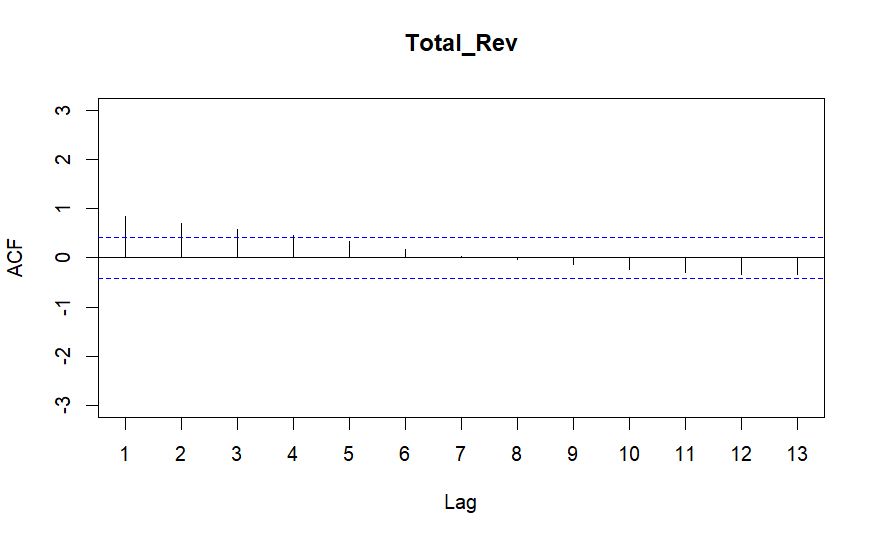

```r
Acf(tsla_5yrRev)
```

Observations:

- ACF Plot of Tesla revenue show a significant correlation with the prior 4 quarters, indicating that the most recent periods will be most indicative of future revenue.
- The plot also shows a steady declining correlation, meaning there is a clear upward trend and no seasonality within their revenue.

Naive & Mean Forecast

```r
mean_fc <- meanf(tsla_5yrRev$Total_Rev, h=4)

mean_fc_a <- accuracy(mean_fc)

mean_fc_a
```

```
                       ME     RMSE      MAE       MPE     MAPE     MASE      ACF1
Training set 1.660894e-13 6931.477 6030.167 -41.98835 70.30611 1.462117 0.8421801
```

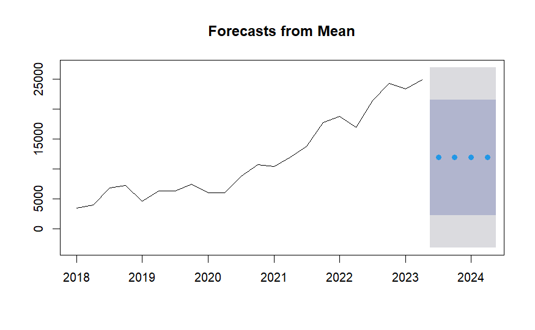

```r
plot(mean_fc)
```

```r
naive_fc <- naive(tsla_5yrRev$Total_Rev, h=4)

naive_fc_a <- accuracy(naive_fc)

naive_fc_a
```

```
                   ME     RMSE      MAE      MPE     MAPE      MASE       ACF1
Training set 1024.679 2087.865 1719.588 6.997179 16.67876 0.4169433 -0.1288419
```

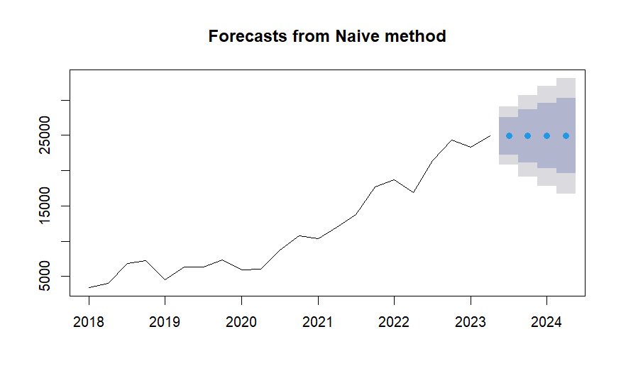

```r
plot(naive_fc)
```

Observations:

- Using the mean as a forecasting method is not appropriate since it does not account for the upward trend shown in the data.
- The naive method also does not appear to acurrately capture the upward trend the data.

Seasonal Naive & Drift Method Forecast

```r
rwf_fc <- rwf(tsla_5yrRev$Total_Rev, h=4, drift = TRUE)

rwf_fc_a <- accuracy(rwf_fc)

rwf_fc_a
```

```
                        ME     RMSE      MAE       MPE     MAPE      MASE       ACF1
Training set -2.814706e-13 1819.124 1473.592 -4.413392 15.91383 0.3572974 -0.1288419
```

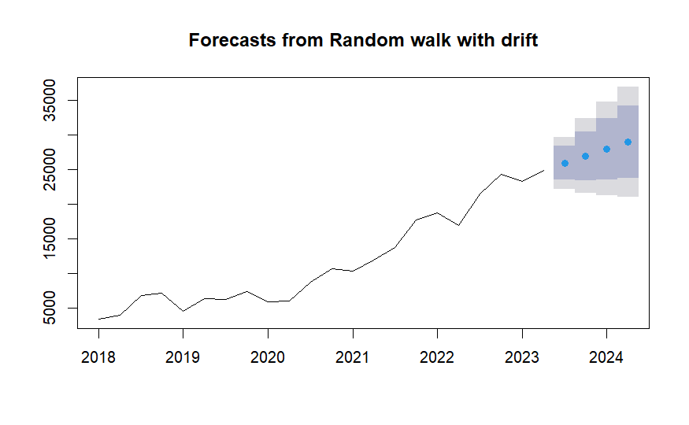

```r
plot(rwf_fc)
```

```r
snaive_fc <- snaive(tsla_5yrRev$Total_Rev, h=4)

snaive_fc_a <- accuracy(snaive_fc)

snaive_fc_a
```

```
                   ME    RMSE      MAE      MPE     MAPE MASE      ACF1
Training set 4031.485 4927.18 4124.273 27.23954 28.73611    1 0.6759198
```

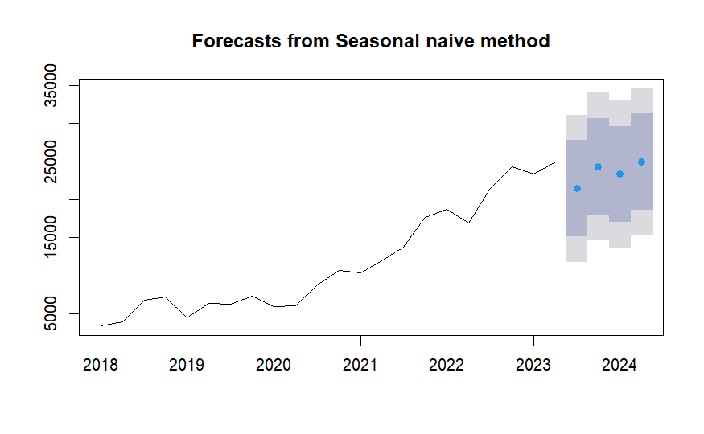

```r
plot(snaive_fc)
```

Observations:

- The Drift method does a better job at capturing the upward trend vs prior methods but shows revenue as continuously increasing which may not be accurate as show by prior period declines.
- The seasonal naive method also shows more modest upward trend but also accounts for periodic decreases in revenue which is in line with actual changes in revenue.

Moving Average Forecasts

```r
ma4_mod <-  ma(tsla_5yrRev$Total_Rev, order = 4)

ma4_fc <- forecast(ma4_mod,4)
attributes(ma4_fc)
```

```
$names
 [1] "model"     "mean"      "level"     "x"         "upper"     "lower"     "fitted"    "method"    "series"    "residuals"

$class
[1] "forecast"
```

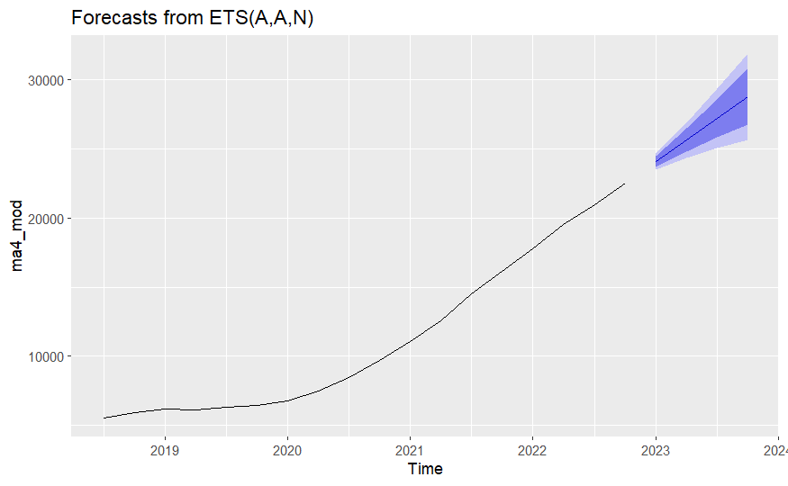

```r
autoplot(ma4_fc)
```

```r
summary(ma4_fc)
```

```
Forecast method: ETS(A,A,N)

Model Information:
ETS(A,A,N)

Call:
 ets(y = object, lambda = lambda, biasadj = biasadj, allow.multiplicative.trend = allow.multiplicative.trend)

  Smoothing parameters:
    alpha = 0.9999
    beta  = 0.9999

  Initial states:
    l = 4760.2368
    b = 861.8574

  sigma:  289.6969

     AIC     AICc      BIC
261.5811 266.5811 266.0330

Error measures:
                   ME     RMSE      MAE       MPE     MAPE       MASE      ACF1
Training set 39.38377 255.4886 227.2001 0.2543139 2.471038 0.05580758 0.1113264

Forecasts:
```

|  | Point Forecast | Lo 80 | Hi 80 | Lo 95 | Hi 95 |
| --- | --- | --- | --- | --- | --- |
| 2023 Q1 | 24078.55 | 23707.29 | 24449.81 | 23510.75 | 24646.34 |
| 2023 Q2 | 25649.24 | 24819.14 | 26479.34 | 24379.72 | 26918.76 |
| 2023 Q3 | 27219.93 | 25830.93 | 28608.93 | 25095.64 | 29344.22 |
| 2023 Q4 | 28790.62 | 26757.34 | 30823.90 | 25680.99 | 31900.25 |

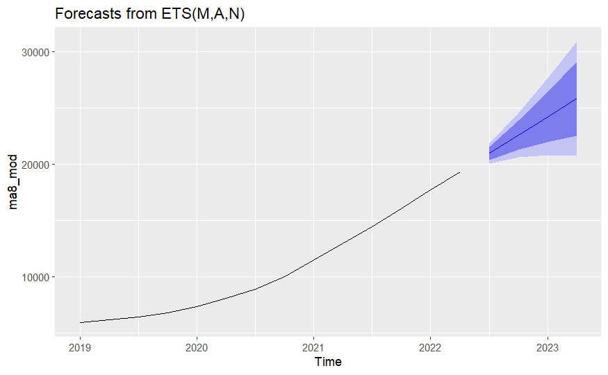

```r
ma4_fc_a <- accuracy(ma4_fc)

ma8_mod <-  ma(tsla_5yrRev$Total_Rev, order = 8)

ma8_fc <- forecast(ma8_mod, 4)
autoplot(ma8_fc)
```

```r
summary(ma8_fc)
```

```
Forecast method: ETS(M,A,N)

Model Information:
ETS(M,A,N)

Call:
 ets(y = object, lambda = lambda, biasadj = biasadj, allow.multiplicative.trend = allow.multiplicative.trend)

  Smoothing parameters:
    alpha = 0.992
    beta  = 0.992

  Initial states:
    l = 5703.9558
    b = 58.4498

  sigma:  0.0216

     AIC     AICc      BIC
192.3852 199.8852 195.5805

Error measures:
                   ME     RMSE      MAE      MPE     MAPE       MASE     ACF1
Training set 112.4262 160.3326 124.6776 1.270047 1.393318 0.02956233 0.221185

Forecasts:
```

|  | Point Forecast | Lo 80 | Hi 80 | Lo 95 | Hi 95 |
| --- | --- | --- | --- | --- | --- |
| 2022 Q3 | 20958.78 | 20379.08 | 21538.47 | 20072.20 | 21845.35 |
| 2022 Q4 | 22578.55 | 21269.62 | 23887.48 | 20576.71 | 24580.39 |
| 2023 Q1 | 24198.33 | 21970.42 | 26426.24 | 20791.03 | 27605.62 |
| 2023 Q2 | 25818.10 | 22496.00 | 29140.20 | 20737.39 | 30898.82 |

```r
ma8_fc_a <- accuracy(ma8_fc)
```

ETS Model

```r
ets_mod <- ets(tsla_5yrRev$Total_Rev)

ets_fc <- forecast(ets_mod, h=4)

attributes(ets_fc)
```

```
$names
 [1] "model"     "mean"      "level"     "x"         "upper"     "lower"     "fitted"    "method"    "series"    "residuals"

$class
[1] "forecast"
```

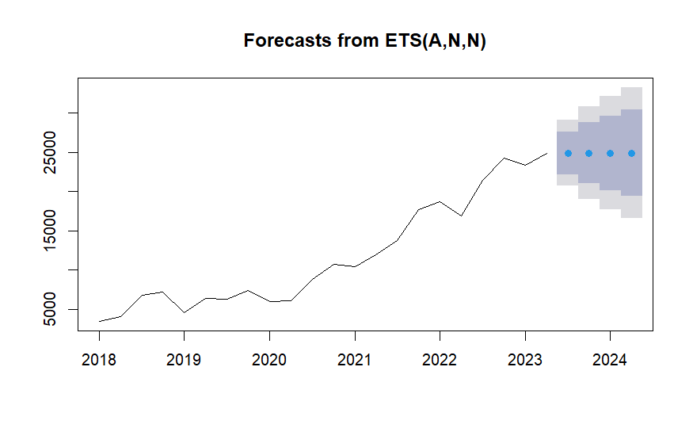

```r
plot(ets_fc)
```

```r
summary(ets_fc)
```

```
Forecast method: ETS(A,N,N)

Model Information:
ETS(A,N,N)

Call:
 ets(y = tsla_5yrRev$Total_Rev)

  Smoothing parameters:
    alpha = 0.9999

  Initial states:
    l = 3415.6241

  sigma:  2139.453

     AIC     AICc      BIC
409.3116 410.6449 412.5847

Error measures:
                   ME     RMSE      MAE      MPE     MAPE      MASE       ACF1
Training set 977.8809 2039.889 1641.745 6.670629 15.92962 0.3980688 -0.1210318

Forecasts:
```

|  | Point Forecast | Lo 80 | Hi 80 | Lo 95 | Hi 95 |
| --- | --- | --- | --- | --- | --- |
| 2023 Q3 | 24926.84 | 22185.02 | 27668.66 | 20733.59 | 29120.09 |
| 2023 Q4 | 24926.84 | 21049.52 | 28804.16 | 18996.98 | 30856.69 |
| 2024 Q1 | 24926.84 | 20178.19 | 29675.49 | 17664.40 | 32189.28 |
| 2024 Q2 | 24926.84 | 19443.61 | 30410.06 | 16540.97 | 33312.71 |

```r
ets_fc_a <- accuracy(ets_fc)
```

Observations:

- ETS method showed that the optimal model is an (ANN) or simple exponential smoothing model where there are additive errors (alpha), no trend (beta=0), and no seasonality in the data (gamma=0).
- The high alpha value of 0.99 shows more recent values get a greater weighting. This model is very close to the naive method.

Holts-Winters Model

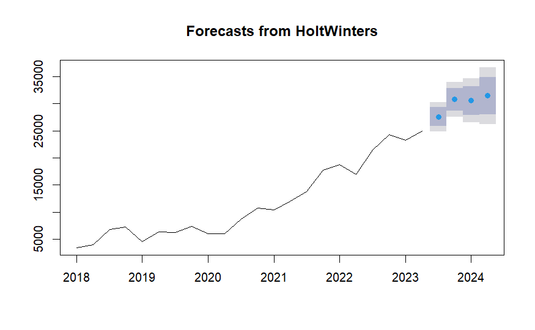

```r
hw_mod <- HoltWinters(tsla_5yrRev$Total_Rev)

hw_fc <- forecast(hw_mod, 4)

plot(hw_fc)
```

```r
attributes(hw_mod)
```

```
$names
[1] "fitted"       "x"            "alpha"        "beta"         "gamma"        "coefficients" "seasonal"     "SSE"
[9] "call"

$class
[1] "HoltWinters"
```

```r
summary(hw_fc)
```

```
Forecast method: HoltWinters

Model Information:
Holt-Winters exponential smoothing with trend and additive seasonal component.

Call:
HoltWinters(x = tsla_5yrRev$Total_Rev)

Smoothing parameters:
 alpha: 0.3088241
 beta : 1
 gamma: 0.6325781

Coefficients:
         [,1]
a  25198.0786
b   1748.6427
s1   647.9110
s2  2111.7563
s3   140.3895
s4  -719.1034

Error measures:
                   ME    RMSE      MAE      MPE     MAPE      MASE       ACF1
Training set 277.1221 1371.78 1151.432 2.694306 10.79645 0.2791842 -0.1290587

Forecasts:
```

|  | Point Forecast | Lo 80 | Hi 80 | Lo 95 | Hi 95 |
| --- | --- | --- | --- | --- | --- |
| 2023 Q3 | 27594.63 | 25822.95 | 29366.31 | 24885.09 | 30304.18 |
| 2023 Q4 | 30807.12 | 28724.75 | 32889.49 | 27622.41 | 33991.83 |
| 2024 Q1 | 30584.40 | 27932.89 | 33235.91 | 26529.26 | 34639.53 |
| 2024 Q2 | 31473.55 | 28035.49 | 34911.60 | 26215.49 | 36731.60 |

```r
hw_fc_a <- accuracy(hw_fc)

hw_mod$alpha
```

```
    alpha
0.3088241
```

```r
hw_mod$beta
```

```
beta
   1
```

```r
hw_mod$gamma
```

```
    gamma
0.6325781
```

```r
hw_mod$SSE
```

```
[1] 33872070
```

Observations - The Holt Winters method shows $\alpha$ = 0.30, $\beta$ = 1, $\gamma$ = 0.63, meaning there is: - Lower alpha means there is a lower importance to more recent values when determining the level (or the average of the values). - Beta of 1 means that the trend or increasing or decreasing component is strongly impacted by the most recent values. - Gamma value of 0.6 means there is some seasonality present in the data that is impacted by somewhat recent values.

Simple Smoothing Equation (SSE) Model

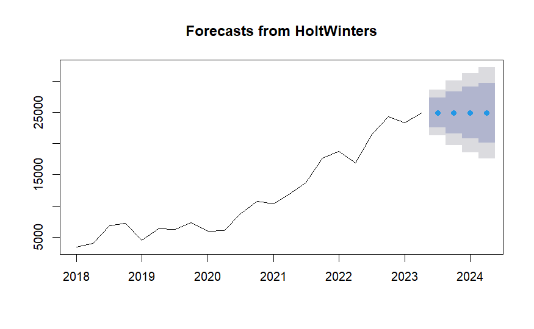

```r
SSE_mod <- HoltWinters(tsla_5yrRev$Total_Rev, beta = FALSE, gamma = FALSE)

SSE_fc <- forecast(SSE_mod, 4)

plot(SSE_fc)
```

```r
summary(SSE_fc)
```

```
Forecast method: HoltWinters

Model Information:
Holt-Winters exponential smoothing without trend and without seasonal component.

Call:
HoltWinters(x = tsla_5yrRev$Total_Rev, beta = FALSE, gamma = FALSE)

Smoothing parameters:
 alpha: 0.9999455
 beta : FALSE
 gamma: FALSE

Coefficients:
      [,1]
a 24926.91

Error measures:
                  ME     RMSE      MAE      MPE     MAPE      MASE       ACF1
Training set 1024.73 2087.879 1719.592 6.997559 16.67866 0.4169443 -0.1288114

Forecasts:
```

|  | Point Forecast | Lo 80 | Hi 80 | Lo 95 | Hi 95 |
| --- | --- | --- | --- | --- | --- |
| 2023 Q3 | 24926.91 | 22538.06 | 27315.77 | 21273.47 | 28580.35 |
| 2023 Q4 | 24926.91 | 21548.65 | 28305.18 | 19760.31 | 30093.52 |
| 2024 Q1 | 24926.91 | 20789.44 | 29064.38 | 18599.20 | 31254.63 |
| 2024 Q2 | 24926.91 | 20149.39 | 29704.43 | 17620.33 | 32233.50 |

```r
SSE_fc_a <- accuracy(SSE_fc)
```

Observations:

- The simple smoothing equation shows that alpha is 0.99, meaning that it follows the naive method, using the most recent value to best predict the next period.
- This can also be observed in the graph which appears to be follow the same time series but lagged by a period.

Plot Simple Models

```r
plot(mean_fc) # Mean Forecast
  lines(naive_fc$mean, col="Blue") # Naive Forecast
```

```r
  lines(rwf_fc$mean, col="Green") # Random Walk Forecast
  lines(snaive_fc$mean, col="Pink") # Seasonal Naive Forecast
```

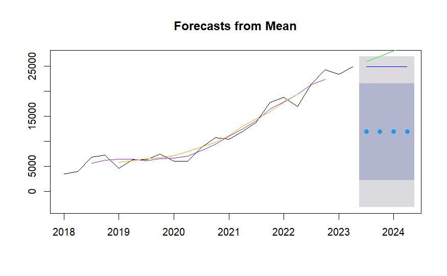

```r
  lines(ma4_fc$fitted, col="Purple") # Moving average 4 periods
  lines(ma8_fc$fitted, col="Orange") # Moving average 8 periods
```

Plot Smoothing Models

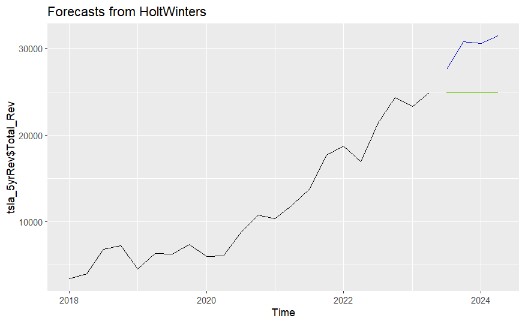

```r
autoplot(hw_fc, color="Blue", alpha = 0.5, PI=FALSE) + # PI attribute removes the confidence interval shading.
  autolayer(ets_fc, series = "mean", color = "Orange", PI=FALSE) + # Not showing in graph because its overlapping with SSE model
  autolayer(SSE_fc, series = "mean", color="Green", PI= FALSE, alpha = 0.5) +
  guides(colour=guide_legend(title="Data series")) # Legend not appearing
```

```r
attributes(ets_fc)
```

```
$names
 [1] "model"     "mean"      "level"     "x"         "upper"     "lower"     "fitted"    "method"    "series"    "residuals"

$class
[1] "forecast"
```

```r
ets_fc$mean
```

```
         Qtr1     Qtr2     Qtr3     Qtr4
2023                   24926.84 24926.84
2024 24926.84 24926.84
```

Accuracy Measures Summary

```r
method <- c('Mean', 'Naive', 'RWF', 'Seasonal Naive', 'MA 4', 'MA 8', 'ETS', 'Holt-Winters', 'SSE')

method <- data.frame(method)

method
```

| method |
| --- |
| Mean |
| Naive |
| RWF |
| Seasonal Naive |
| MA 4 |
| MA 8 |
| ETS |
| Holt-Winters |
| SSE |

```r
acu_table <- data.frame(rbind(mean_fc_a, naive_fc_a, rwf_fc_a, snaive_fc_a, ma4_fc_a, ma8_fc_a, ets_fc_a, hw_fc_a, SSE_fc_a))

acu_table <- data.frame(cbind(method, acu_table))

format_table(acu_table)
```

|  | method | ME | RMSE | MAE | MPE | MAPE | MASE | ACF1 |
| --- | --- | --- | --- | --- | --- | --- | --- | --- |
| Training.set | Mean | 1.660894e-13 | 6931.4769 | 6030.1674 | -41.9883540 | 70.306107 | 1.46211652 | 0.8421801 |
| Training.set.1 | Naive | 1.024679e+03 | 2087.8646 | 1719.5880 | 6.9971787 | 16.678764 | 0.41694331 | -0.1288419 |
| Training.set.2 | RWF | -2.814706e-13 | 1819.1241 | 1473.5920 | -4.4133925 | 15.913830 | 0.35729741 | -0.1288419 |
| Training.set.3 | Seasonal Naive | 4.031485e+03 | 4927.1802 | 4124.2728 | 27.2395352 | 28.736114 | 1.00000000 | 0.6759198 |
| Training.set.4 | MA 4 | 3.938377e+01 | 255.4886 | 227.2001 | 0.2543139 | 2.471038 | 0.05580758 | 0.1113264 |
| Training.set.5 | MA 8 | 1.124262e+02 | 160.3326 | 124.6776 | 1.2700468 | 1.393318 | 0.02956233 | 0.2211850 |
| Training.set.6 | ETS | 9.778809e+02 | 2039.8885 | 1641.7445 | 6.6706294 | 15.929622 | 0.39806885 | -0.1210318 |
| Training.set.7 | Holt-Winters | 2.771221e+02 | 1371.7805 | 1151.4317 | 2.6943058 | 10.796453 | 0.27918418 | -0.1290587 |
| Training.set.8 | SSE | 1.024730e+03 | 2087.8794 | 1719.5921 | 6.9975588 | 16.678661 | 0.41694431 | -0.1288114 |

```r
NA
```